# **Regresion Lineal**

Lorena Guevara Cortina

22/03/2021

*Índice*

1. Historia
2. Definición
3. Modelo de regresión lineal simple

   > Ejemplo
4. Modelo de regresión lineal multiple

   > Ejemplo

## Historia

[figure not shown]

La primera forma de regresión lineal documentada fue el método de los mínimos cuadrados que fue publicada por Legendre en 1805, Gauss publicó un trabajo en donde desarrollaba de manera más profunda el método de los mínimos cuadrados, y en dónde se incluía una versión del teorema de Gauss-Márkov.

El término regresión se utilizó por primera vez en el estudio de variables antropométricas: al comparar la estatura de padres e hijos, donde resultó que los hijos cuyos padres tenían una estatura muy superior al valor medio, tendían a igualarse a este, mientras que aquellos cuyos padres eran muy bajos tendían a reducir su diferencia respecto a la estatura media; es decir, "regresaban" al promedio. La constatación empírica de esta propiedad se vio reforzada más tarde con la justificación teórica de ese fenómeno.

El término lineal se emplea para distinguirlo del resto de técnicas de regresión, que emplean modelos basados en cualquier clase de función matemática. Los modelos lineales son una explicación simplificada de la realidad, mucho más ágiles y con un soporte teórico mucho más extenso por parte de la matemática y la estadística.

Pero bien, como se ha dicho, se puede usar el término lineal para distinguir modelos basados en cualquier clase de aplicación. [tomado de.](https://es.wikipedia.org/wiki/Regresi%C3%B3n_lineal#:~:text=La%20primera%20forma%20de%20regresi%C3%B3n,del%20teorema%20de%20Gauss%2DM%C3%A1rkov.)

## Definición

Desde el punto de vista matemático, la Regresión tiene dos significados: uno surge de la distribución conjunta de probabilidades de dos variables aleatorias mientras que el otro significado es empírico y nace de la necesidad de ajustar alguna función a un conjunto de datos.

Dos de las implementaciones de modelos de regresión lineal más utilizadas en Python son: *scikit-learn* y *statsmodels*. Aunque ambas están muy optimizadas, *Scikit-learn* está orientada principalmente a la predicción, por lo que no dispone de apenas funcionalidades que muestren las muchas características del modelo que se deben analizar para hacer inferencia. *Statsmodels* es mucho más completo en este sentido.

## Modelo de regresión lineal simple

La regresión lineal simple parte de una sóla variable predictora, es decir $X=x_i$ donde $X \in \mathbb{R}$ y supone que existe aproximadamente una relación lineal entre $X$ e $Y$. Esta relación lineal puede ser escrita como:

$$ Y = \beta_0 + \beta_1 X + \epsilon $$

La parte $\beta_0 + \beta_1 X $ es el modelo de regresion lineal, siendo $\beta_0$ y $\beta_1$ los coeficientes de regresion lineal y $\epsilon$ el error cometido por el modelo.

Los términos $\beta_0$ y $\beta_1$ representan respectivamente el interceptor y la pendiente del modelo lineal. Son lo que se denomina coeficientes o parámetros del modelo de regresión lineal. Estos dos coeficientes son dos constantes que se obtienen por medio de lo que se denomina *entrenamiento* del modelo de regresión. Este entrenamiento se realiza con datos de los que sabemos valores reales de la tupla $(X,Y)$. Una vez obtenida la estimación de estos dos coeficientes se puede predecir la variable $Y$ usando $X$ conocidos y a partir de la siguiente fórmula:

$$ \hat{y}=\hat{\beta}_0 + \hat{\beta}_1 x $$

Siendo $\hat{y}$ la predicción que obtenemos y $\hat{\beta}_0 $ y $\hat{\beta}_1$ estimaciones obtenidas con el entrenamiento. Si el término de error $\epsilon$ es bajo para esta muestra, nuestra predicción será aproximadamente igual al valor real:

$$ \hat{y} \approx y $$

Por lo tanto, el entrenamiento y ajuste del modelo de regresión simple tratará de obtener los valores de $\hat{\beta}_0 $ y $\hat{\beta}_1$ que mejor ajusten el modelo, es decir, mejor predigan el $Y$ en función de $X$.

#### Estimación por mínimos cuadrados

Siendo $\hat{y_i}=\hat{\beta}_0 + \hat{\beta}_1 x_i$ las predicciones de $y_i$, el residuo o diferencia entre la predicción y el valor real es:

$$ r_i = y_i - \hat{y}_i $$

El método de mínimos cuadrados obtendrá los coeficientes que minimicen la suma de residuos al cuadrado, es decir, que minimicen:

$$ RSS = \sum_{i=1}^{n} r_i^{2} $$

Usando derivadas parciales e igualando a $0$ obtenemos que:

$$ \frac{\delta RSS}{\delta \hat{\beta}_1} = 0 \quad \Longrightarrow \quad \hat{\beta}_1 = \frac{\sum_{i=1}^{n} (x_i - \tilde{x})(y_i - \tilde{y})}{\sum_{i=1}^{n} (x_i - \tilde{x})^2} \ $$$$ \frac{\delta RSS}{\delta \hat{\beta}_0} = 0 \quad \Longrightarrow \quad \hat{\beta}_0 = \tilde{y} - \hat{\beta}_1 \tilde{x} \quad \quad \quad \quad \quad $$

Siendo $\tilde{x}$ e $\tilde{y}$ las medias aritméticas de las muestras.

### Ejemplo

Datos de salarios de acuerdo a los años de experiencia

```python
import numpy as np
import pandas as pd
import matplotlib.pyplot as plt
import csv
%matplotlib inline
from sklearn.model_selection import train_test_split
from sklearn import linear_model
```

- Primero visualizamos los datos completos

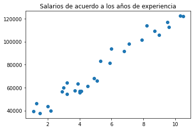

```python
datos = open(r"C:\Users\lorel\Downloads\Notbook_Diplomado\Datos_salario.csv")
salario = pd.read_csv(datos)
x = salario.iloc[:, :-1].values
y = salario.iloc[:, 1].values

plt.scatter(x, y)
plt.title('Salarios de acuerdo a los años de experiencia')
plt.show()
```

- Ahora separamos los datos en entrenamiento y testeo

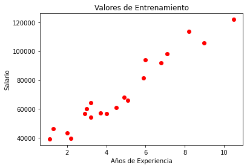

```python
x_train, x_test, y_train, y_test = train_test_split(x, y, test_size=1/3, random_state=0)

plt.scatter(x_train, y_train, color='red')
plt.title('Valores de Entrenamiento')
plt.xlabel('Años de Experiencia')
plt.ylabel('Salario')
plt.show()
```

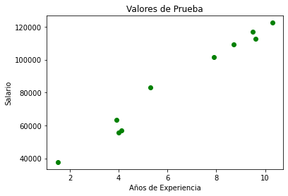

```python
plt.scatter(x_test, y_test, color='green')
plt.title('Valores de Prueba')
plt.xlabel('Años de Experiencia')
plt.ylabel('Salario')
plt.show()
```

- Ahora con los datos de entrenamiento modelamos la regresion lineal

```python
regresion = linear_model.LinearRegression()
regresion.fit(x_train, y_train)
y_pred = regresion.predict(x_test)
```

- Comparamos las predicciones del modelo con los valores reales

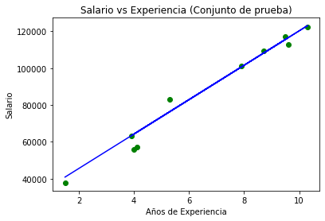

```python
plt.scatter(x_test, y_test, color = 'green')
plt.plot(x_test, y_pred, color = 'blue')
plt.title('Salario vs Experiencia (Conjunto de prueba)')
plt.xlabel('Años de Experiencia')
plt.ylabel('Salario')
plt.show()
```

## Modelo de regresión lineal multiple

En la práctica solemos tener n variables predictoras. Podríamos hacer $n$ regresiones lineales simples, pero cada una de ellas ignoraría a las otras $n-1$ variables y no se sacaría ventaja de las relaciones entre variables. La regresión lineal simple puede extenderse para el caso de n variables como:

$$ y = \beta_0 + \beta_1 x_1 + \beta_2 x_2 + \cdots + \beta_n x_n + \epsilon $$

En este caso a cada variable predictora le asignamos un coeficiente que marca la pendiente. Estos coeficientes $\beta_i$ marcan la relación lineal entre $y$ y la variable $x_i$. Se puede interpretar como el efecto medio en $Y$ de un incremento de una unidad en $x_i$, manteniendo el resto de variables predictoras fijas.

Análogamente a la regresión lineal simple, podemos obtener estimaciones $\hat{\beta}_i$ de los coeficientes $\beta_i$ mediante el entrenamiento y posteriormente hacer predicciones de $Y$ usando la fórmula:

$$ \hat{y} = \hat{\beta}_0 + \hat{\beta}_1 x_1 + \hat{\beta}_2 x_2 + \cdots + \hat{\beta}_n x_n $$

Estos parámetros son calculados usando minimos cuadrados. Calculamos los $\hat{\beta}_i$ que minimizan la suma de residuos al cuadrado:

$$ RSS = \sum_{i=1}^{n} r_i^{2} = \sum_{i=1}^{n} (y_i - \hat{\beta}_0 + \hat{\beta}_1 x_1 + \cdots + \hat{\beta}_i x_i)^2 $$

### Ejemplo

Prediccion de numeros de likes que tienen una cierta publicación. [Link PDF de los datos](https://drive.google.com/file/d/1JSup27qQ0SKMbaxnGXEuScrKjfvWE0ah/view)

```python
datos2 = open(r"C:\Users\lorel\Downloads\Notbook_Diplomado\dataset_Facebook.csv")
dataset = pd.read_csv(datos2)
```

```python
dataset = dataset.replace(np.nan,"0")
share = dataset['share'].values
hour = dataset['Post Hour'].values
days = dataset['Post Weekday'].values
likes = dataset['like'].values
interaction = dataset['Total Interactions'].values
```

```python
X = np.array([hour, days, interaction]).T
Y = np.array(likes)
regresionM = linear_model.LinearRegression()
regresionM.fit(X,Y)
Y_pred = regresionM.predict(X)
```

```python
from sklearn.metrics import mean_squared_error

error = np.sqrt(mean_squared_error(Y,Y_pred))
r2 = regresionM.score(X,Y)
print("El error es,", error)
print("El valor de r^2 es,", r2)
print("Los coeficientes son,", regresionM.coef_)
```

```
El error es, 21.81953867915251
El valor de r^2 es, 0.9954323615919498
Los coeficientes son, [ 0.21551007 -0.40017767  0.84787796]
```